# Primera parte - R: Vuelos de NYC

En este análisis se trabaja con una base de datos que reúne información como detalle de vuelos, información de aerolíneas, información de aeropuertos, datos sobre aeronaves como también datos meterológicos de vuelos que salieron de NYC. El enfoque inicial es identificar patrones para permitir entender mejor qué variables afectan o tienen una mayor relación.

**Mostrar código**

```r
library(DBI)
library(RSQLite)
library(dplyr)
library(tidyr)
library(ggplot2)

library(corrplot)
```

**Mostrar código**

```r
# Para mayor oportunidad de descarga
options(timeout = 300)  # 5 minutos

#URL del documento
url <- "https://raw.githubusercontent.com/EduardoSelimMM/20260101_LecturaLimpiezaDatos/main/proyecto/vuelos.db"

temp <- tempfile(fileext = ".db")

#Descarga parcial del documento
download.file(url, temp, mode = "wb", method = "libcurl")
con <- DBI::dbConnect(RSQLite::SQLite(), temp)
```

Luego de hacer uso de las librerías y haber llamado la base de datos podemos dar una visualización general de su estructura.

### Análisis de la información

Observamos que se tienen cinco tablas:

**Mostrar código**

```r
dbListTables(con)
```

```
[1] "aerolineas"  "aeropuertos" "aviones"     "clima"       "vuelos"
```

**Mostrar código**

```r
vuelos <- dbReadTable(con, "vuelos")
aviones <- dbReadTable(con, "aviones")
clima <-dbReadTable(con, "clima")
aerolineas <- dbReadTable(con, "aerolineas")
aeropuertos <- dbReadTable(con, "aeropuertos")
```

Comenzando un poco con la inspección de las tablas podemos identificar las conexión que se tiene, esto será utilizado más adelante considerando cada una de las preguntas que se contestarán.

Nota: Para el análisis de los retrasos, se realizó una recodificación de los valores negativos, asignándoles un valor de cero, de manera que estos se interpreten como vuelos que salieron o llegaron a tiempo o incluso de forma anticipada, sin penalizar el promedio de retrasos.

Esto se debe a que, al promediar valores positivos y negativos directamente, los vuelos adelantados pueden compensar los retrasos, lo que reduce el promedio y no refleja de forma adecuada el comportamiento real de los retrasos.

Por otro lado, si se consideran únicamente los valores mayores a cero, el promedio se vería sesgado al excluir vuelos que no presentaron retraso, lo que sobreestima la magnitud del problema.

Por ello, se opta por una tercera alternativa: considerar los valores negativos como cero, lo cual permite obtener un indicador más representativo del retraso real promedio, sin eliminar observaciones ni distorsionar el comportamiento del conjunto de datos.

# Pregunta 1.

### ¿Qué aerolínea tuvo el mayor retraso promedio en la salida en 2013?

## Consulta con dplyr

**Mostrar código**

```r
q1 <- vuelos %>%
  mutate(dep_delay = ifelse(dep_delay < 0, 0, dep_delay)) %>%
  group_by(carrier) %>%
  summarise(promedio = mean(dep_delay, na.rm = TRUE)) %>%
  left_join(aerolineas, by = "carrier") %>%
  select(name, promedio) %>%
  arrange(desc(promedio)) %>%
  mutate(rank = row_number())

q1[1:3,1:2]
```

| name | promedio |
| --- | --- |
| ExpressJet Airlines Inc. | 22.67663 |
| Mesa Airlines Inc. | 22.63853 |
| Frontier Airlines Inc. | 22.56891 |

## Consulta con SQL

**Mostrar código**

```r
dbGetQuery(con, "
SELECT
  ae.name,
  AVG(CASE
        WHEN dep_delay < 0 THEN 0
        ELSE dep_delay
      END) AS promedio

FROM vuelos AS v
LEFT JOIN aerolineas AS ae
  ON v.carrier = ae.carrier

WHERE v.dep_delay IS NOT NULL

GROUP BY ae.name

ORDER BY promedio DESC

LIMIT 3
")
```

| name | promedio |
| --- | --- |
| ExpressJet Airlines Inc. | 22.67663 |
| Mesa Airlines Inc. | 22.63853 |
| Frontier Airlines Inc. | 22.56891 |

*Gráfico:*

**Mostrar código**

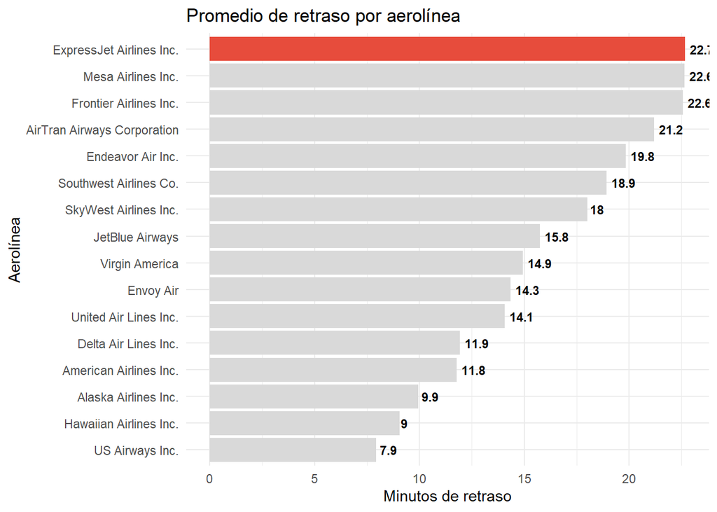

```r
ggplot(q1, aes(x = reorder(name, promedio), y = promedio)) +
  geom_col(aes(fill = rank == 1)) +
  coord_flip() +
  geom_text(
    data = q1,
    aes(label = round(promedio, 1)),
    hjust = -0.2,
    size = 3,
    fontface = "bold"
  ) +
  scale_fill_manual(values = c("TRUE" = "#E74C3C", "FALSE" = "grey85")) +
  labs(
    title = "Promedio de retraso por aerolínea",
    x = "Aerolínea",
    y = "Minutos de retraso"
  ) +
  theme_minimal() +
  theme(legend.position = "none")
```

Podemos ver que, a partir de las dos consultas, la aerolínea ExpressJet Airlines Inc. es la que presenta el mayor promedio de retrasos, con una diferencia de 0.03810 respecto a Mesa Airlines Inc. y de 0.10772 respecto a Frontier Airlines Inc.

# Pregunta 2.

### ¿Qué día de la semana tuvo más vuelos retrasados en promedio?

## Consulta con dplyr

**Mostrar código**

```r
q2 <- vuelos %>%
  mutate(
    fecha = as.Date(paste(year, month, day, sep = "-")),
    dia_semana = weekdays(fecha)
        ) %>%
  mutate(dep_delay = ifelse(dep_delay < 0, 0, dep_delay)) %>%
  group_by(dia_semana) %>%
  summarise(
    promedio = mean(dep_delay, na.rm = TRUE),
    total_retrasos = n()
           ) %>%
  arrange(desc(promedio))%>%
  mutate(rank = row_number())

q2[1:3,1:3]
```

| dia_semana | promedio | total_retrasos |
| --- | --- | --- |
| jueves | 18.62445 | 50219 |
| lunes | 17.45836 | 50690 |
| viernes | 17.18209 | 50308 |

## Consulta con SQL

**Mostrar código**

```r
dbGetQuery(con, "
SELECT
  CASE strftime('%w', date(printf('%04d-%02d-%02d', year, month, day)))
    WHEN '0' THEN 'domingo'
    WHEN '1' THEN 'lunes'
    WHEN '2' THEN 'martes'
    WHEN '3' THEN 'miercoles'
    WHEN '4' THEN 'jueves'
    WHEN '5' THEN 'viernes'
    WHEN '6' THEN 'sabado'
  END AS dia_semana,
  AVG(CASE
        WHEN dep_delay < 0 THEN 0
        ELSE dep_delay
      END) AS promedio,
  COUNT(*) AS total_retrasos

FROM vuelos

WHERE dep_delay IS NOT NULL

GROUP BY dia_semana

ORDER BY promedio DESC

LIMIT 3
")
```

| dia_semana | promedio | total_retrasos |
| --- | --- | --- |
| jueves | 18.62445 | 48657 |
| lunes | 17.45836 | 49470 |
| viernes | 17.18209 | 48700 |

*Gráfico:*

**Mostrar código**

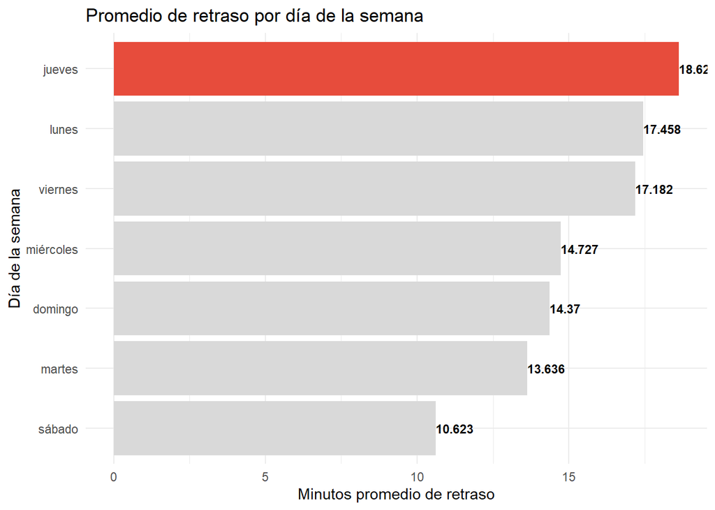

```r
ggplot(q2, aes(x = reorder(dia_semana, promedio), y = promedio)) +
  geom_col(aes(fill = rank == 1)) +
  coord_flip() +
  geom_text(
    data = q2,
    aes(label = round(promedio,3)),
    hjust = 0,
    size = 3,
    fontface= "bold"
  )+
  scale_fill_manual(values=c("TRUE"="#E74C3C", "FALSE" = "grey85"))+
  labs(
    title = "Promedio de retraso por día de la semana",
    x = "Día de la semana",
    y = "Minutos promedio de retraso"
  )+
 theme_minimal() +
  theme(legend.position = "none")
```

El jueves presentó el mayor retraso promedio con 18.62 minutos, seguido del lunes con 17.46 minutos. Esto sugiere que los días de mayor actividad en la semana laboral tienden a presentar mayores retrasos, posiblemente debido al incremento en la demanda de vuelos y la congestión operativa asociada a viajes de trabajo.

# Pregunta 3.

### ¿Cuál es la distribución de los retrasos en la salida para cada aeropuerto?

## Consulta con dplyr

**Mostrar código**

```r
q3 <- vuelos %>%
  mutate(dep_delay = ifelse(dep_delay < 0, 0, dep_delay)) %>%
  group_by(origin) %>%
  summarise(
    promedio = mean(dep_delay, na.rm = TRUE),
    mediana  = median(dep_delay, na.rm = TRUE),
    minimo   = min(dep_delay, na.rm = TRUE),
    maximo   = max(dep_delay, na.rm = TRUE),
    p25      = quantile(dep_delay, 0.25, na.rm = TRUE),
    p75      = quantile(dep_delay, 0.75, na.rm = TRUE),
    desviacion = sd(dep_delay,na.rm = TRUE)
  ) %>%
  left_join(aeropuertos, by = c("origin" = "faa")) %>%
  select(name, promedio, mediana, minimo, maximo, p25, p75,desviacion) %>%
  arrange(desc(promedio))

q3
```

| name | promedio | mediana | minimo | maximo | p25 | p75 | desviacion |
| --- | --- | --- | --- | --- | --- | --- | --- |
| Newark Liberty Intl | 17.47587 | 0 | 0 | 1126 | 0 | 15 | 40.19457 |
| John F Kennedy Intl | 14.61527 | 0 | 0 | 1301 | 0 | 10 | 37.97230 |
| La Guardia | 13.81697 | 0 | 0 | 911 | 0 | 7 | 38.60717 |

## Consulta con SQL

**Mostrar código**

```r
dbGetQuery(con, "
SELECT
    ae.name,
    AVG(CASE WHEN v.dep_delay < 0 THEN 0 ELSE v.dep_delay END) AS promedio,
    MIN(CASE WHEN v.dep_delay < 0 THEN 0 ELSE v.dep_delay END) AS minimo,
    MAX(CASE WHEN v.dep_delay < 0 THEN 0 ELSE v.dep_delay END) AS maximo,
    PERCENT_RANK() OVER (ORDER BY AVG(CASE WHEN v.dep_delay < 0 THEN 0 ELSE v.dep_delay END) DESC) AS ranking_percentil

FROM vuelos AS v
JOIN aeropuertos AS ae
    ON v.origin = ae.faa

WHERE v.dep_delay IS NOT NULL

GROUP BY ae.name

ORDER BY promedio DESC
")
```

| name | promedio | minimo | maximo | ranking_percentil |
| --- | --- | --- | --- | --- |
| Newark Liberty Intl | 17.47587 | 0 | 1126 | 0.0 |
| John F Kennedy Intl | 14.61527 | 0 | 1301 | 0.5 |
| La Guardia | 13.81697 | 0 | 911 | 1.0 |

Se analizó la distribución de los retrasos de salida para cada aeropuerto origen, calculando las medidas descriptivas como promedio, mínimo, máximo de retrasos.

*Gráficos:*

**Mostrar código**

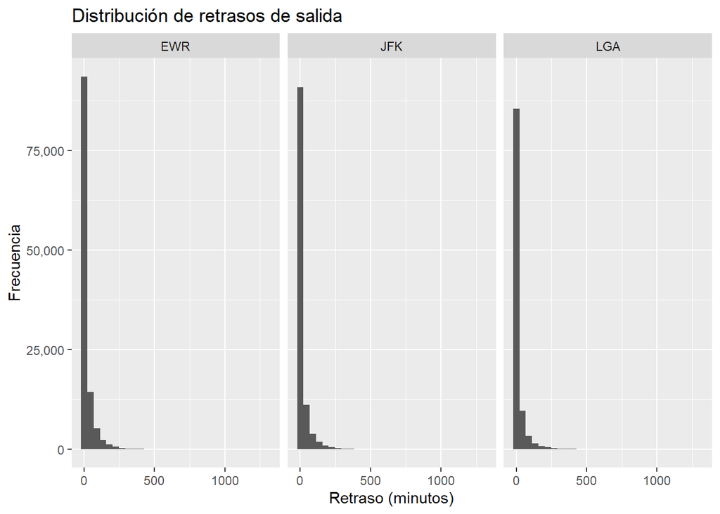

```r
vuelos %>%
  mutate(dep_delay = ifelse(dep_delay < 0, 0, dep_delay))%>%
  filter(!is.na(dep_delay)) %>%
  ggplot(aes(x = dep_delay)) +
  geom_histogram(bins = 30) +
  facet_wrap(~origin) +
  scale_y_continuous(labels = scales::comma)+
  labs(
    title = "Distribución de retrasos de salida",
    x = "Retraso (minutos)",
    y = "Frecuencia"
  )
```

La gráfica muestra la distribución de los retrasos de salida en los aeropuertos EWR, JFK y LGA.

Se observa que en los tres aeropuertos la mayor parte de los vuelos tiene retrasos pequeños, ya que las barras más altas se concentran cerca de los 0 minutos. Conforme aumenta el tiempo de retraso, la frecuencia disminuye considerablemente.

Además, la distribución está sesgada hacia la derecha, lo que indica que existen algunos vuelos con retrasos extremadamente altos, aunque son poco frecuentes.

**Mostrar código**

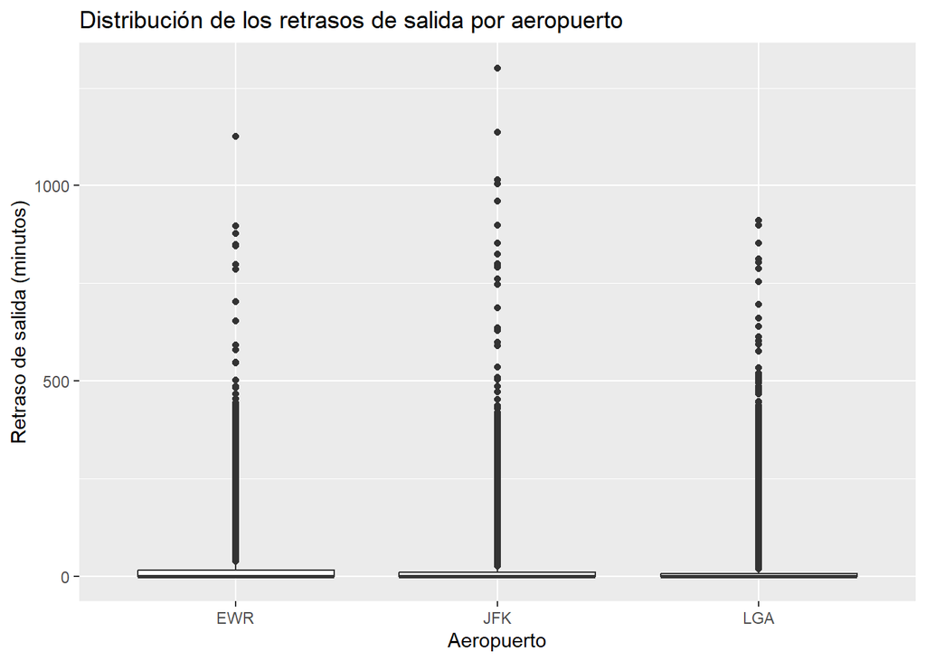

```r
vuelos %>%
  mutate(dep_delay = ifelse(dep_delay < 0, 0, dep_delay)) %>%
  ggplot(aes(x = origin, y = dep_delay)) +
  geom_boxplot() +
  labs(
    title = "Distribución de los retrasos de salida por aeropuerto",
    x = "Aeropuerto",
    y = "Retraso de salida (minutos)"
  )
```

El boxplot muestra que los tres aeropuertos presentan una fuere asimetría positiva, la mayoría d elos vueles tienen retrasos relativamente bajos, pero existen algunos casos extremos con retrasos muy elevados. Observandose valores atípicos en los 3 aeropuertos.

LaGuardia presenta el menor retraso promedio entre los tres aeropuertos analizados, con aproximadamente 13.82 minutos, seguido de John F. Kennedy International Airport con 14.62 minutos, mientras que Newark Liberty International Airport registra el mayor promedio con 17.48 minutos. No obstante, John F Kennedy Intl presenta algunos de los retrasos máximos más elevados, alcanzando hasta 1301 minutos, lo que evidencia la existencia de casos extremos significativamente altos.

# Pregunta 4.

### ¿Qué proporción de vuelos se retrasaron más de 30 minutos?

## Consulta con dplyr

**Mostrar código**

```r
q4 <- vuelos %>%
  filter(!is.na(dep_delay)) %>%
  summarise(
    total = n(),
    retrasados = sum(dep_delay > 30),
    proporcion = (retrasados / total)*100
  )

q4
```

| total | retrasados | proporcion |
| --- | --- | --- |
| 328521 | 48291 | 14.69952 |

## Consulta con SQL

**Mostrar código**

```r
dbGetQuery(con, "
SELECT
    COUNT(*) AS total,
    SUM(CASE WHEN dep_delay > 30 THEN 1 ELSE 0 END) AS retrasos,
    (1.0*SUM(CASE WHEN dep_delay > 30 THEN 1 ELSE 0 END) / COUNT(*))*100 AS proporcion

FROM vuelos

WHERE dep_delay IS NOT NULL
AND dep_delay>0
")
```

| total | retrasos | proporcion |
| --- | --- | --- |
| 128432 | 48291 | 37.60044 |

**Mostrar código**

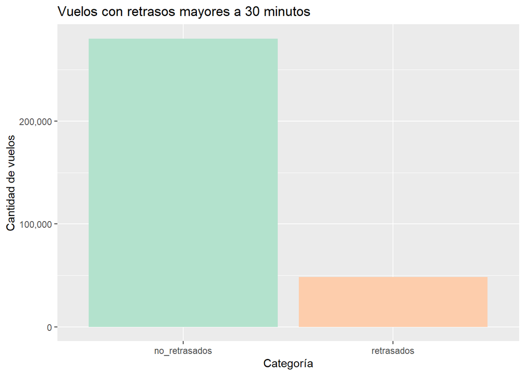

```r
q4_graf <- q4 %>%
  mutate(no_retrasados = total - retrasados) %>%
  select(retrasados, no_retrasados) %>%
  pivot_longer(cols = everything(),
               names_to = "categoria",
               values_to = "cantidad")

ggplot(q4_graf, aes(x = categoria, y = cantidad, fill = categoria)) +
  scale_fill_brewer(palette = "Pastel2")+
  scale_y_continuous(labels = scales::comma)+
  geom_bar(stat = "identity") +
  labs(
    title = "Vuelos con retrasos mayores a 30 minutos",
    x = "Categoría",
    y = "Cantidad de vuelos"
  )+
  theme(legend.position = "none")
```

Se observa que la mayoría de los vuelos retrasados no supera los 30 minutos de demora. Sin embargo, existe una proporción importante de vuelos con retrasos superiores a 30 minutos, lo que indica que una parte considerable de las demoras puede afectar significativamente los tiempos de salida.

# Pregunta 5.

### ¿Qué destinos tuvieron los mayores retrasos promedio en la llegada?

## Consulta en dplyr

**Mostrar código**

```r
q5 <- vuelos %>%
  mutate(arr_delay = ifelse(arr_delay < 0, 0, arr_delay)) %>%
  group_by(dest) %>%
  summarise(
    promedio = mean(arr_delay, na.rm = TRUE),
    total_vuelos = n()
  ) %>%
  left_join(aeropuertos, by = c("dest" = "faa")) %>%
  select(name, promedio, total_vuelos) %>%
  arrange(desc(promedio))

q5[1:3,1:3]
```

| name | promedio | total_vuelos |
| --- | --- | --- |
| Columbia Metropolitan | 44.01887 | 116 |
| Tulsa Intl | 39.63265 | 315 |
| Will Rogers World | 36.09206 | 346 |

**Mostrar código**

```r
q5.1 <- vuelos %>%
  mutate(arr_delay = ifelse(arr_delay < 0, 0, arr_delay)) %>%
  group_by(dest) %>%
  summarise(
    promedio = mean(arr_delay, na.rm = TRUE),
    total_vuelos = n(),
    .groups = "drop"
  ) %>%
  filter(total_vuelos >= median(total_vuelos)) %>%
  left_join(aeropuertos, by = c("dest" = "faa")) %>%
  select(name, promedio, total_vuelos) %>%
  arrange(desc(promedio))

q5.1[1:3,1:3]
```

| name | promedio | total_vuelos |
| --- | --- | --- |
| Richmond Intl | 27.18798 | 2454 |
| Kansas City Intl | 23.91300 | 2008 |
| Cincinnati Northern Kentucky Intl | 23.62336 | 3941 |

## Consulta con SQL

**Mostrar código**

```r
dbGetQuery(con, "
SELECT
  a.name,
  AVG(CASE WHEN v.arr_delay < 0 THEN 0 ELSE v.arr_delay END) AS promedio,
  COUNT(*) AS total_vuelos

FROM vuelos AS v
LEFT JOIN aeropuertos AS a
  ON v.dest = a.faa

WHERE v.arr_delay IS NOT NULL

GROUP BY v.dest, a.name

ORDER BY promedio DESC

LIMIT 3;
           ")
```

| name | promedio | total_vuelos |
| --- | --- | --- |
| Columbia Metropolitan | 44.01887 | 106 |
| Tulsa Intl | 39.63265 | 294 |
| Will Rogers World | 36.09206 | 315 |

*Gráfico:*

**Mostrar código**

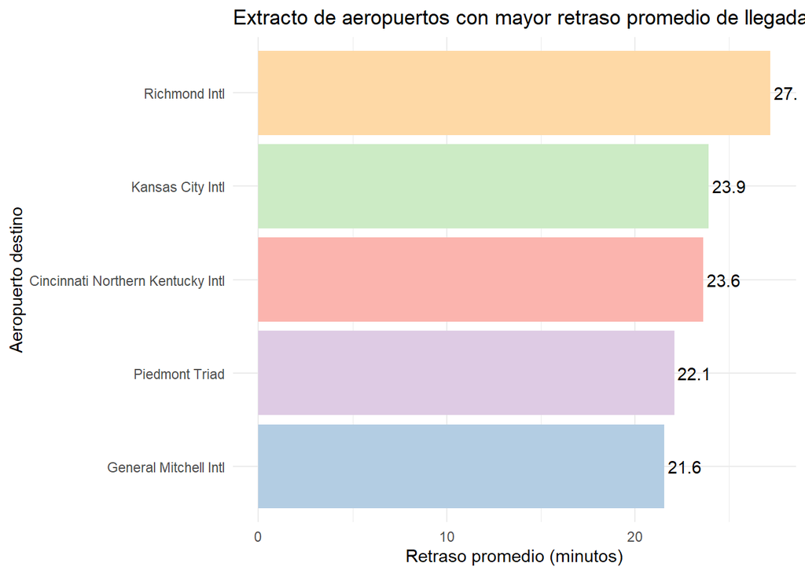

```r
q5.1 %>%
  slice_max(promedio, n = 5) %>%
  ggplot(aes(x = reorder(name, promedio),
             y = promedio,
             fill = name)) +
  geom_col() +
  coord_flip() +
  scale_fill_brewer(palette = "Pastel1")+
  scale_y_continuous(labels = scales::comma) +
  geom_text(aes(label = round(promedio, 1)),
            hjust = -0.1) +
  labs(
    title = "Extracto de aeropuertos con mayor retraso promedio de llegada",
    x = "Aeropuerto destino",
    y = "Retraso promedio (minutos)"
  ) +
  theme_minimal() +
  theme(legend.position = "none")
```

Sin considerar la totalidad de los vuelos, los destinos con mayores retrasos son Columbia Metropolitan, Tulsa Intl y Will Rogers World, con valores superiores a 30 minutos. Los mayores retrasos promedio se observan en ciertos aeropuertos con menor volumen de vuelos, teniendo en cuenta que los valores extremos pueden tener un mayor impacto en el promedio cuando el tamaño de la muestra es reducido.

Por otro lado, tomando la mediana del total de vuelos, tenemos que los destinos con mayores retrasos promedio en la llegada fueron Richmond Intl (27.19 min), Kansas City Intl (23.91 min) y Cincinnati/Northern Kentucky Intl (23.62 min).

# Pregunta 6.

### ¿Qué aerolíneas tuvieron el mayor número de vuelos desde NYC?

## Consulta en dplyr

**Mostrar código**

```r
q6 <- vuelos %>%
  group_by(carrier) %>%
  summarise(total = n(), .groups = "drop") %>%
  mutate(proporcion = (total / sum(total))*100) %>%
  left_join(aerolineas, by = "carrier") %>%
  select(name, total, proporcion) %>%
  arrange(desc(total))

q6[1:3,1:3]
```

| name | total | proporcion |
| --- | --- | --- |
| United Air Lines Inc. | 58665 | 17.41959 |
| JetBlue Airways | 54635 | 16.22295 |
| ExpressJet Airlines Inc. | 54173 | 16.08577 |

## Consulta con SQL

**Mostrar código**

```r
dbGetQuery(con,"
SELECT
  ae.name,
  COUNT(*) AS total,
  (COUNT(*) * 1.0 / (
    SELECT COUNT(*)
    FROM vuelos
  ))*100 AS proporcion
FROM vuelos AS v
LEFT JOIN aerolineas AS ae
  ON v.carrier = ae.carrier
GROUP BY v.carrier, ae.name
ORDER BY total DESC;
                   ")
```

| name | total | proporcion |
| --- | --- | --- |
| United Air Lines Inc. | 58665 | 17.419590470 |
| JetBlue Airways | 54635 | 16.222949379 |
| ExpressJet Airlines Inc. | 54173 | 16.085766207 |
| Delta Air Lines Inc. | 48110 | 14.285459771 |
| American Airlines Inc. | 32729 | 9.718329097 |
| Envoy Air | 26397 | 7.838147611 |
| US Airways Inc. | 20536 | 6.097821698 |
| Endeavor Air Inc. | 18460 | 5.481388222 |
| Southwest Airlines Co. | 12275 | 3.644855928 |
| Virgin America | 5162 | 1.532769556 |

[output cut: 6 more lines]

*Gráfico:*

**Mostrar código**

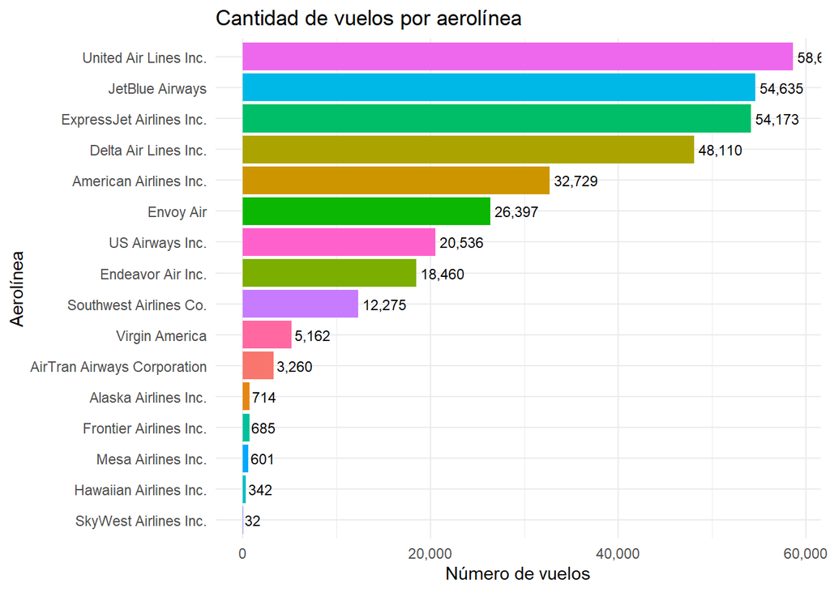

```r
q6 %>%
  ggplot(aes(x = reorder(name, total),
             y = total,
             fill = name)) +
  geom_col() +
  geom_text(aes(label = scales::comma(total)),
            hjust = -0.1,
            size = 3) +
  coord_flip() +
  scale_y_continuous(labels = scales::comma) +
  labs(
    title = "Cantidad de vuelos por aerolínea",
    x = "Aerolínea",
    y = "Número de vuelos",
    fill = "Proporción (%)"
  ) +
  theme_minimal()+
  theme(legend.position = "none")
```

Las aerolíneas con mayor número de vuelos desde NYC fueron *United Air Lines Inc.*, *JetBlue Airways* y *ExpressJet Airlines Inc.*, con 58,665, 54,635 y 54,173 vuelos respectivamente. Estas tres aerolíneas concentran una proporción importante del total de operaciones, lo que indica que dominan gran parte del tráfico aéreo de salida desde los aeropuertos de Nueva York.

# Pregunta 7.

### ¿Cómo varía el retraso de los vuelos según el fabricante de la aeronave?

## Consulta con dplyr

**Mostrar código**

```r
q7 <- vuelos %>%
  mutate(arr_delay = ifelse(arr_delay < 0, 0, arr_delay))%>%
  left_join(aviones, by = "tailnum") %>%
  filter(!is.na(manufacturer)) %>%
  group_by(manufacturer) %>%
  summarise(
    promedio = mean(arr_delay, na.rm = TRUE),
    mediana  = median(arr_delay, na.rm = TRUE),
    total_vuelos = n()
  ) %>%
  arrange(desc(promedio))

q7[1:5,1:4]
```

| manufacturer | promedio | mediana | total_vuelos |
| --- | --- | --- | --- |
| AGUSTA SPA | 41.70968 | 5 | 32 |
| AVIAT AIRCRAFT INC | 25.29412 | 0 | 18 |
| CANADAIR | 23.89477 | 0 | 1594 |
| FRIEDEMANN JON | 22.51786 | 0 | 63 |
| BELL | 21.11111 | 0 | 65 |

## Consulta con SQL

**Mostrar código**

```r
dbGetQuery(con, "
SELECT
  a.manufacturer,
  AVG(CASE WHEN v.arr_delay < 0 THEN 0 ELSE v.arr_delay END) AS promedio,
  COUNT(*) AS total_vuelos
FROM vuelos AS v
LEFT JOIN aviones AS a
  ON v.tailnum = a.tailnum
WHERE a.manufacturer IS NOT NULL
GROUP BY a.manufacturer
ORDER BY promedio DESC
LIMIT 5;
")
```

| manufacturer | promedio | total_vuelos |
| --- | --- | --- |
| AGUSTA SPA | 41.70968 | 32 |
| AVIAT AIRCRAFT INC | 25.29412 | 18 |
| CANADAIR | 23.89477 | 1594 |
| FRIEDEMANN JON | 22.51786 | 63 |
| BELL | 21.11111 | 65 |

*Gráfico:*

**Mostrar código**

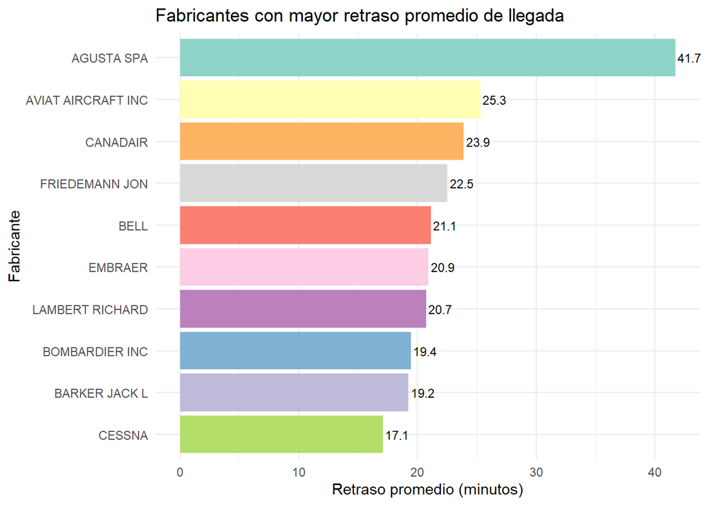

```r
q7 %>%
  slice_max(promedio, n = 10) %>%
  ggplot(aes(x = reorder(manufacturer, promedio),
             y = promedio,
             fill = manufacturer)) +
  geom_col() +
  geom_text(aes(label = round(promedio,1)),
            hjust = -0.1,
            size = 3) +
  scale_fill_brewer(palette = "Set3") +
  coord_flip() +
  scale_y_continuous(labels = scales::comma) +
  labs(
    title = "Fabricantes con mayor retraso promedio de llegada",
    x = "Fabricante",
    y = "Retraso promedio (minutos)"
  ) +
  theme_minimal() +
  theme(legend.position = "none")
```

Se observa que algunos fabricantes presentan retrasos promedio considerablemente más altos que otros. Por ejemplo, AGUSTA SPA y AVIAT AIRCRAFT INC registran los mayores promedios de retraso, con aproximadamente 41.71 minutos y 25.29 minutos, respectivamente.

# Pregunta 8.

### ¿Los aviones más antiguos tienen más retrasos?

## Consulta con dplyr

**Mostrar código**

```r
q8 <- vuelos %>%
  left_join(aviones, by = "tailnum") %>%
  group_by(anio_fabricacion = year.y) %>%
  summarise(retraso_prom_salida = mean(dep_delay, na.rm = TRUE)) %>%
  filter(!is.na(anio_fabricacion)) %>%
  arrange(anio_fabricacion)

q8
```

| anio_fabricacion | retraso_prom_salida |
| --- | --- |
| 1956 | 5.954545 |
| 1959 | 9.928571 |
| 1963 | 8.078431 |
| 1965 | -4.000000 |
| 1967 | 10.272727 |
| 1968 | 10.463415 |
| 1972 | 17.583333 |
| 1973 | 6.181818 |
| 1974 | 9.365591 |
| 1975 | 13.021978 |

[output cut: 36 more lines]

## Consulta con SQL

**Mostrar código**

```r
dbGetQuery(con, "
SELECT a.year AS anio_fabricacion, AVG(v.dep_delay) AS retraso_prom_salida
FROM vuelos v
JOIN aviones a ON v.tailnum = a.tailnum
WHERE a.year IS NOT NULL
GROUP BY a.year
ORDER BY a.year
")
```

| anio_fabricacion | retraso_prom_salida |
| --- | --- |
| 1956 | 5.954545 |
| 1959 | 9.928571 |
| 1963 | 8.078431 |
| 1965 | -4.000000 |
| 1967 | 10.272727 |
| 1968 | 10.463415 |
| 1972 | 17.583333 |
| 1973 | 6.181818 |
| 1974 | 9.365591 |
| 1975 | 13.021978 |

[output cut: 36 more lines]

*Gráfico:*

**Mostrar código**

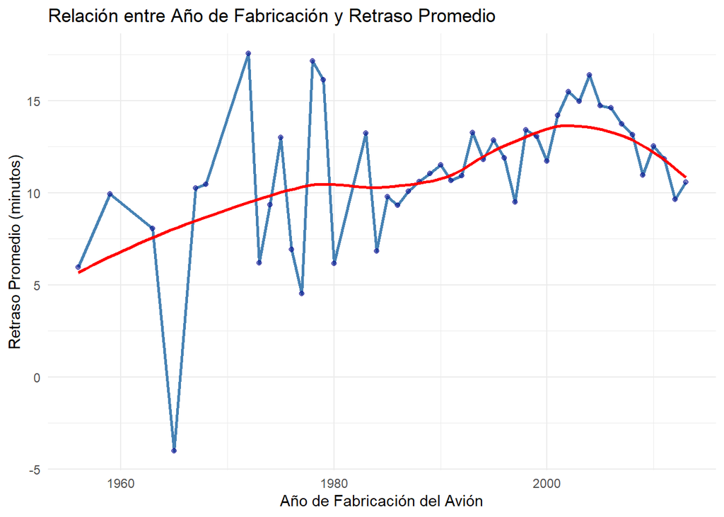

```r
# Generamos una gráfica para una mejor visualización
retrasos_por_anio <- vuelos %>%
  left_join(aviones, by = "tailnum") %>%
  group_by(anio_fabricacion = year.y) %>%
  summarise(retraso_prom_salida = mean(dep_delay, na.rm = TRUE)) %>%
  filter(!is.na(anio_fabricacion))

ggplot(retrasos_por_anio, aes(x = anio_fabricacion, y = retraso_prom_salida)) +
  geom_line(color = "steelblue", size = 1) +
  geom_point(color = "darkblue", alpha = 0.5) +
  geom_smooth(method = "loess", color = "red", se = FALSE) +
  labs(title = "Relación entre Año de Fabricación y Retraso Promedio",
       x = "Año de Fabricación del Avión",
       y = "Retraso Promedio (minutos)") +
  theme_minimal()
```

Al analizar los datos, no se observa una tendencia que indique que los aviones más antiguos se retrasen sustancialmente más. Los retrasos promedio fluctúan a lo largo de los años de fabricación, sugiriendo que factores como el clima, la aerolínea o la congestión del aeropuerto influyen más que el tiempo del avion.

# Pregunta 9.

### ¿Qué modelos de aviones se utilizan con mayor frecuencia en vuelos desde NYC?

## Consulta con dplyr

**Mostrar código**

```r
q9 <- vuelos %>%
  left_join(aviones, by = "tailnum") %>%
  group_by(model) %>%
  summarise(frecuencia = n()) %>%
  filter(!is.na(model)) %>%
  arrange(desc(frecuencia)) %>%
  head(10)

q9
```

| model | frecuencia |
| --- | --- |
| A320-232 | 45831 |
| EMB-145LR | 28027 |
| ERJ 190-100 IGW | 23716 |
| EMB-145XR | 14051 |
| 737-824 | 13809 |
| CL-600-2D24 | 11807 |
| 737-7H4 | 10389 |
| MD-88 | 10191 |
| A319-114 | 9713 |
| CL-600-2B19 | 9588 |

## Consulta con SQL

**Mostrar código**

```r
dbGetQuery(con, "
SELECT a.model, COUNT(*) AS frecuencia
FROM vuelos v
JOIN aviones a ON v.tailnum = a.tailnum
WHERE a.model IS NOT NULL
GROUP BY a.model
ORDER BY frecuencia DESC
LIMIT 10
")
```

| model | frecuencia |
| --- | --- |
| A320-232 | 45831 |
| EMB-145LR | 28027 |
| ERJ 190-100 IGW | 23716 |
| EMB-145XR | 14051 |
| 737-824 | 13809 |
| CL-600-2D24 | 11807 |
| 737-7H4 | 10389 |
| MD-88 | 10191 |
| A319-114 | 9713 |
| CL-600-2B19 | 9588 |

Los modelos preferidos para rutas desde NYC pertenecen predominantemente a A320-232 y EMB- 145LR. Esto responde a la alta demanda de vuelos comerciales de mediano y corto alcance operados por las principales aerolíneas

# Pregunta 10.

### ¿Cuál es la distancia promedio de vuelo por aerolínea?

## Consulta con dplyr

**Mostrar código**

```r
q10 <- vuelos %>%
  group_by(carrier) %>%
  summarise(distancia_promedio = mean(distance, na.rm = TRUE)) %>%
  arrange(desc(distancia_promedio))

q10
```

| carrier | distancia_promedio |
| --- | --- |
| HA | 4983.0000 |
| VX | 2499.4822 |
| AS | 2402.0000 |
| F9 | 1620.0000 |
| UA | 1529.1149 |
| AA | 1340.2360 |
| DL | 1236.9012 |
| B6 | 1068.6215 |
| WN | 996.2691 |
| FL | 664.8294 |

[output cut: 6 more lines]

## Consulta con SQL

**Mostrar código**

```r
dbGetQuery(con, "
SELECT carrier, AVG(distance) AS distancia_promedio
FROM vuelos
GROUP BY carrier
ORDER BY distancia_promedio DESC
")
```

| carrier | distancia_promedio |
| --- | --- |
| HA | 4983.0000 |
| VX | 2499.4822 |
| AS | 2402.0000 |
| F9 | 1620.0000 |
| UA | 1529.1149 |
| AA | 1340.2360 |
| DL | 1236.9012 |
| B6 | 1068.6215 |
| WN | 996.2691 |
| FL | 664.8294 |

[output cut: 6 more lines]

Aerolíneas como HA (Hawaiian Airlines)tienen la mayor distancia promedio de vuelo, dada la naturaleza de sus rutas (como el trayecto JFK-HNL). Por el contrario, aerolíneas regionales o de conexión manejan distancias promedio mucho más cortas.

# Pregunta 11.

### ¿Qué aeropuerto de NYC tuvo el mayor número de retrasos en la salida?

## Consulta con dplyr

**Mostrar código**

```r
q11 <- vuelos %>%
  filter(dep_delay > 0) %>%
  group_by(origin) %>%
  summarise(num_vuelos_retrasados = n()) %>%
  arrange(desc(num_vuelos_retrasados))

q11
```

| origin | num_vuelos_retrasados |
| --- | --- |
| EWR | 52711 |
| JFK | 42031 |
| LGA | 33690 |

## Consulta con SQL

**Mostrar código**

```r
dbGetQuery(con, "
SELECT origin, COUNT(*) AS num_vuelos_retrasados
FROM vuelos
WHERE dep_delay > 0
GROUP BY origin
ORDER BY num_vuelos_retrasados DESC
")
```

| origin | num_vuelos_retrasados |
| --- | --- |
| EWR | 52711 |
| JFK | 42031 |
| LGA | 33690 |

*Gráfico:*

**Mostrar código**

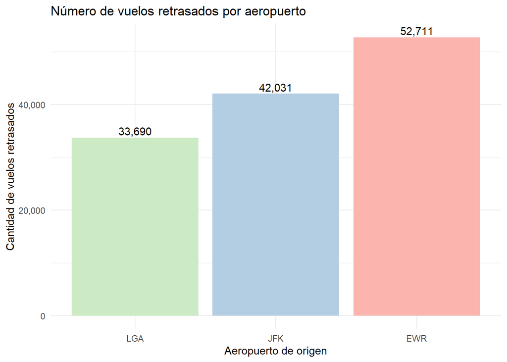

```r
ggplot(q11,
       aes(x = reorder(origin, num_vuelos_retrasados),
           y = num_vuelos_retrasados,
           fill = origin)) +
  geom_col() +
  geom_text(aes(label = scales::comma(num_vuelos_retrasados)),
            vjust = -0.3) +
  scale_y_continuous(labels = scales::comma) +
  scale_fill_brewer(palette = "Pastel1") +
  labs(
    title = "Número de vuelos retrasados por aeropuerto",
    x = "Aeropuerto de origen",
    y = "Cantidad de vuelos retrasados"
  ) +
  theme_minimal() +
  theme(legend.position = "none")
```

El aeropuerto de EWR (Newark) y JFK acumulan históricamente la mayor cantidad de vuelos con un retraso, lo cual tiene sentido dado su alto volumen de tráfico aéreo y configuración de pistas en relación al clima de la región.

# Pregunta 12.

### ¿Qué aeropuerto tuvo el menor tiempo promedio de taxi-out?

## Consulta con dplyr

**Mostrar código**

```r
q12 <- vuelos %>%
  mutate(proxy_taxi_out = arr_delay - dep_delay) %>%
  group_by(origin) %>%
  summarise(tiempo_taxi_out_promedio = mean(proxy_taxi_out, na.rm = TRUE)) %>%
  arrange(tiempo_taxi_out_promedio)

q12
```

| origin | tiempo_taxi_out_promedio |
| --- | --- |
| JFK | -6.472126 |
| EWR | -5.902055 |
| LGA | -4.503095 |

## Consulta con SQL

**Mostrar código**

```r
dbGetQuery(con, "
SELECT origin, AVG(arr_delay - dep_delay) AS tiempo_taxi_out_promedio
FROM vuelos
GROUP BY origin
ORDER BY tiempo_taxi_out_promedio ASC
")
```

| origin | tiempo_taxi_out_promedio |
| --- | --- |
| JFK | -6.472126 |
| EWR | -5.902055 |
| LGA | -4.503095 |

# Pregunta 13.

### ¿Qué porcentaje de vuelos que salen de cada aeropuerto de NYC fueron puntuales?

## Consulta con dplyr

**Mostrar código**

```r
q13 <- vuelos %>%
  group_by(origin) %>%
  summarise(pct_puntualidad = mean(dep_delay <= 0, na.rm = TRUE) * 100) %>%
  arrange(desc(pct_puntualidad))

q13
```

| origin | pct_puntualidad |
| --- | --- |
| LGA | 66.81082 |
| JFK | 61.58606 |
| EWR | 55.17620 |

## Consulta con SQL

**Mostrar código**

```r
dbGetQuery(con, "
SELECT origin,
       AVG(CASE WHEN dep_delay <= 0 THEN 1.0 ELSE 0.0 END) * 100 AS pct_puntualidad
FROM vuelos
GROUP BY origin
ORDER BY pct_puntualidad DESC
")
```

| origin | pct_puntualidad |
| --- | --- |
| LGA | 64.79811 |
| JFK | 60.55500 |
| EWR | 53.69719 |

*Gráfico:*

**Mostrar código**

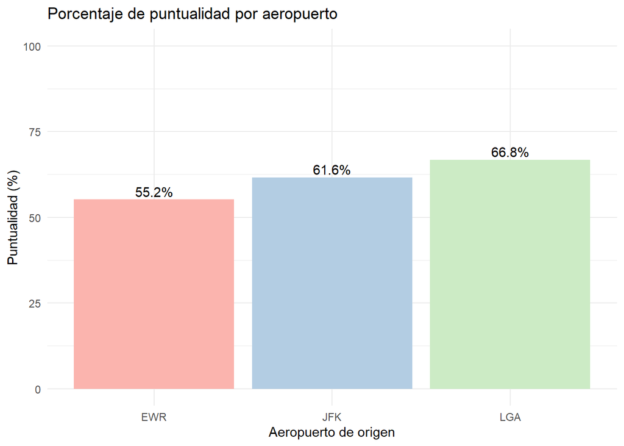

```r
ggplot(q13,
       aes(x = reorder(origin, pct_puntualidad),
           y = pct_puntualidad,
           fill = origin)) +
  geom_col() +
  geom_text(aes(label = paste0(round(pct_puntualidad,1), "%")),
            vjust = -0.3) +
  scale_fill_brewer(palette = "Pastel1") +
  labs(
    title = "Porcentaje de puntualidad por aeropuerto",
    x = "Aeropuerto de origen",
    y = "Puntualidad (%)"
  ) +
  ylim(0, 100) +
  theme_minimal() +
  theme(legend.position = "none")
```

LGA (LaGuardia) suele destacar con el porcentaje más alto de vuelos que logran salir con puntualidad, superando a aeropuertos con mayores problemas de saturación o clima, como EWR.

# Pregunta 14.

### ¿Qué aeropuertos de destino tienen el mayor retraso promedio en la llegada para vuelos desde NYC?

## Consulta con dplyr

**Mostrar código**

```r
q14 <- vuelos %>%
  mutate(arr_delay = ifelse(arr_delay < 0, 0, arr_delay))%>%
  filter(
    !is.na(arr_delay),
    origin %in% c("JFK", "LGA", "EWR")
  ) %>%
  left_join(aeropuertos, by=c("dest"="faa")) %>%
  group_by(dest,name) %>%
  summarise(
    promedio = mean(arr_delay),
    total_vuelos = n()
  ) %>%
  arrange(desc(promedio))

q14
```

| dest | name | promedio | total_vuelos |
| --- | --- | --- | --- |
| CAE | Columbia Metropolitan | 44.018868 | 106 |
| TUL | Tulsa Intl | 39.632653 | 294 |
| OKC | Will Rogers World | 36.092063 | 315 |
| TYS | Mc Ghee Tyson | 31.797578 | 578 |
| JAC | Jackson Hole Airport | 29.476190 | 21 |
| DSM | Des Moines Intl | 28.349904 | 523 |
| RIC | Richmond Intl | 27.187980 | 2346 |
| MSN | Dane Co Rgnl Truax Fld | 27.050360 | 556 |
| BHM | Birmingham Intl | 27.014870 | 269 |
| CAK | Akron Canton Regional Airport | 25.527316 | 842 |

[output cut: 94 more lines]

**Mostrar código**

```r
q14.1 <- vuelos %>%
  mutate(arr_delay = ifelse(arr_delay < 0, 0, arr_delay))%>%
  filter(
    !is.na(arr_delay),
    origin %in% c("JFK", "LGA", "EWR")
  ) %>%
  left_join(aeropuertos, by=c("dest"="faa")) %>%
  group_by(dest,name) %>%
  summarise(
    promedio = mean(arr_delay),
    total_vuelos = n()
  ) %>%
  filter(total_vuelos >= 100) %>%
  arrange(desc(promedio))

q14.1
```

| dest | name | promedio | total_vuelos |
| --- | --- | --- | --- |
| CAE | Columbia Metropolitan | 44.018868 | 106 |
| TUL | Tulsa Intl | 39.632653 | 294 |
| OKC | Will Rogers World | 36.092063 | 315 |
| TYS | Mc Ghee Tyson | 31.797578 | 578 |
| DSM | Des Moines Intl | 28.349904 | 523 |
| RIC | Richmond Intl | 27.187980 | 2346 |
| MSN | Dane Co Rgnl Truax Fld | 27.050360 | 556 |
| BHM | Birmingham Intl | 27.014870 | 269 |
| CAK | Akron Canton Regional Airport | 25.527316 | 842 |
| GRR | Gerald R Ford Intl | 24.001374 | 728 |

[output cut: 82 more lines]

## Consulta con SQL

**Mostrar código**

```r
dbGetQuery(con, "
SELECT
    a.name,
    AVG(CASE WHEN v.arr_delay < 0 THEN 0 ELSE v.arr_delay END) AS prom_arr_delay,
    COUNT(*) AS total_vuelos
FROM vuelos v
JOIN aeropuertos a
    ON v.dest = a.faa
WHERE v.arr_delay IS NOT NULL
  AND v.origin IN ('JFK', 'LGA', 'EWR')
GROUP BY a.name
HAVING COUNT(*) >= 100
ORDER BY prom_arr_delay DESC;
")
```

| name | prom_arr_delay | total_vuelos |
| --- | --- | --- |
| Columbia Metropolitan | 44.018868 | 106 |
| Tulsa Intl | 39.632653 | 294 |
| Will Rogers World | 36.092063 | 315 |
| Mc Ghee Tyson | 31.797578 | 578 |
| Des Moines Intl | 28.349904 | 523 |
| Richmond Intl | 27.187980 | 2346 |
| Dane Co Rgnl Truax Fld | 27.050360 | 556 |
| Birmingham Intl | 27.014870 | 269 |
| Akron Canton Regional Airport | 25.527316 | 842 |
| Gerald R Ford Intl | 24.001374 | 728 |

[output cut: 78 more lines]

Los aeropuertos de destino con mayor retraso promedio en la llegada de vuelos incluyen Columbia Metropolitan (CAE), Tulsa Intl (TUL) y Will Rogers World (OKC), con promedios cercanos a los 40 minutos. En el análisis se considera únicamente a los destinos con más de 100 vuelos, con el fin de evitar distorsiones en los resultados causadas por aeropuertos con baja frecuencia de operaciones.

# Pregunta 15.

### ¿Cómo varían los retrasos en la salida según la hora del día en cada aeropuerto de NYC?

## Consulta con dplyr

**Mostrar código**

```r
q15 <- vuelos %>%
  mutate(arr_delay = ifelse(dep_delay < 0, 0, dep_delay)) %>%
  group_by(origin, hour) %>%
  summarise(
    promedio_retraso = mean(dep_delay, na.rm = TRUE),
    total_vuelos = n()
  ) %>%
  arrange(origin, hour)
```

## Consulta con SQL

**Mostrar código**

```r
dbGetQuery(con, "
SELECT
  origin,
  hour,
  AVG(CASE WHEN dep_delay< 0 THEN 0 ELSE dep_delay END) AS promedio_retraso,
  COUNT(*) AS total_vuelos
FROM vuelos
WHERE dep_delay IS NOT NULL
GROUP BY origin, hour
ORDER BY origin, hour;
")
```

| origin | hour | promedio_retraso | total_vuelos |
| --- | --- | --- | --- |
| EWR | 5 | 3.989910 | 892 |
| EWR | 6 | 6.610001 | 10959 |
| EWR | 7 | 6.976112 | 8540 |
| EWR | 8 | 8.754224 | 9114 |
| EWR | 9 | 8.811113 | 5993 |
| EWR | 10 | 10.897124 | 6571 |
| EWR | 11 | 10.997960 | 4903 |
| EWR | 12 | 14.123492 | 6964 |
| EWR | 13 | 15.806550 | 8886 |
| EWR | 14 | 19.127603 | 6818 |

[output cut: 46 more lines]

*Gráficos:*

**Mostrar código**

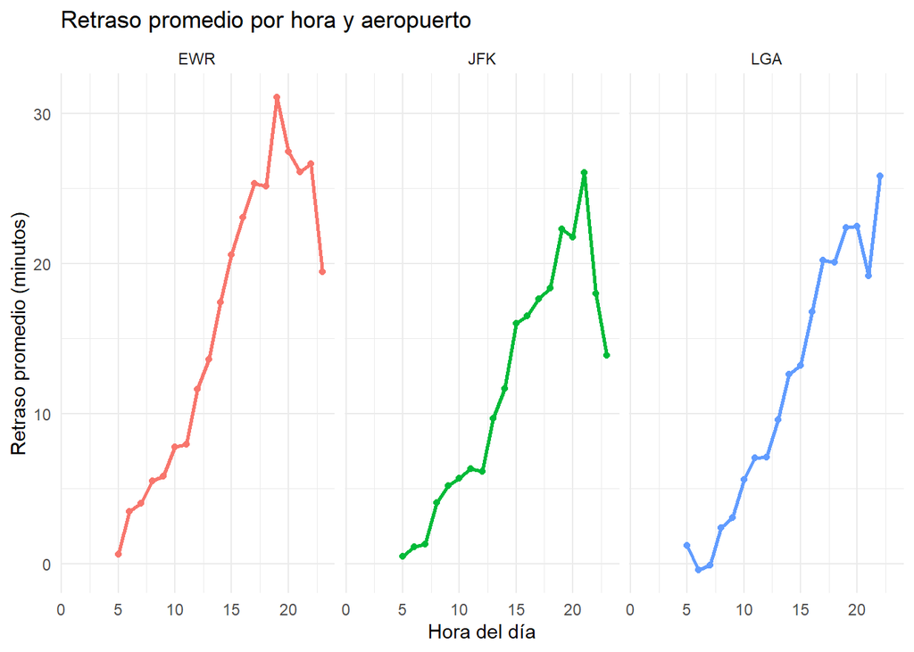

```r
ggplot(q15,
       aes(x = hour,
           y = promedio_retraso,
           color = origin,
           group = origin)) +
  geom_line(size = 1) +
  geom_point() +
  facet_wrap(~origin) +
  scale_fill_brewer(palette = "Pastel1") +
  labs(
    title = "Retraso promedio por hora y aeropuerto",
    x = "Hora del día",
    y = "Retraso promedio (minutos)"
  ) +
  theme_minimal() +
  theme(legend.position = "none")
```

Los retrasos en la salida muestran un patrón claro de aumento conforme avanza el día en los tres aeropuertos de NYC (EWR, JFK y LGA). En general, los vuelos programados en las primeras horas de la mañana (5–9 am) presentan los menores retrasos promedio, mientras que los valores aumentan progresivamente a lo largo del día, teniendo los valores más altos por la noche.

# Pregunta 16.

### ¿Cuál es la correlación entre la velocidad del viento y los retrasos en la salida?

## Consulta con dplyr

**Mostrar código**

```r
q16 <- vuelos %>%
  left_join(clima, by = c("origin", "time_hour"))%>%
  filter(!is.na(wind_speed), !is.na(dep_delay))%>%
  summarise(correlation = cor(wind_speed, dep_delay, use = "complete.obs"))

q16
```

| correlation |
| --- |
| 0.04742427 |

## Consulta con SQL

**Mostrar código**

```r
dbGetQuery(con, "
SELECT
  (
    AVG(c.wind_speed * v.dep_delay) -
    AVG(c.wind_speed) * AVG(v.dep_delay)
  ) /
  (
    SQRT(AVG(c.wind_speed * c.wind_speed) - AVG(c.wind_speed) * AVG(c.wind_speed)) *
    SQRT(AVG(v.dep_delay * v.dep_delay) - AVG(v.dep_delay) * AVG(v.dep_delay))
  ) AS correlation
FROM vuelos AS v
JOIN clima AS c
  ON v.origin = c.origin
 AND v.time_hour = c.time_hour
WHERE c.wind_speed IS NOT NULL
  AND v.dep_delay IS NOT NULL;
")
```

| correlation |
| --- |
| 0.04742427 |

El valor de la correlación entre la velocidad del viento y los retrasos en la salida es de 0.04742427*, lo que indica una relación positiva prácticamente nula. Esto nos da que la velocidad del viento no tiene un impacto relevante sobre los retrasos en la salida de los vuelos desde NYC.

# Pregunta 17.

### ¿Los vuelos experimentan más retrasos en días con lluvias intensas?

## Consulta con dplyr

**Mostrar código**

```r
q17 <- vuelos %>%
  left_join(clima, by = c("origin", "time_hour")) %>%
  filter(
    !is.na(precip),
    !is.na(dep_delay),
    !is.na(arr_delay),
    dep_delay > 0,
    arr_delay > 0
  ) %>%
  mutate(
    nivel_lluvia = case_when(
      precip == 0 ~ "Sin lluvia",
      precip < 0.1 ~ "Ligera",
      precip < 0.5 ~ "Moderada",
      TRUE ~ "Intensa"
    )
  ) %>%
  group_by(nivel_lluvia) %>%
  summarise(
    promedio_dep = mean(dep_delay, na.rm = TRUE),
    promedio_arr = mean(arr_delay, na.rm = TRUE),
    total_vuelos = n()
  )

q17
```

| nivel_lluvia | promedio_dep | promedio_arr | total_vuelos |
| --- | --- | --- | --- |
| Intensa | 80.71910 | 82.78652 | 89 |
| Ligera | 61.50491 | 68.55303 | 8146 |
| Moderada | 72.89479 | 80.64467 | 2167 |
| Sin lluvia | 49.86135 | 50.08914 | 81393 |

## Consulta con SQL

**Mostrar código**

```r
dbGetQuery(con, "

SELECT
  CASE
    WHEN c.precip = 0 THEN 'Sin lluvia'
    WHEN c.precip < 0.1 THEN 'Ligera'
    WHEN c.precip < 0.5 THEN 'Moderada'
    ELSE 'Intensa'
  END AS nivel_lluvia,

  AVG(v.dep_delay) AS promedio_dep,
  AVG(v.arr_delay) AS promedio_arr,
  COUNT(*) AS total_vuelos

FROM vuelos AS v

JOIN clima AS c
  ON v.origin = c.origin
 AND v.time_hour = c.time_hour

WHERE c.precip IS NOT NULL
  AND v.dep_delay > 0
  AND v.arr_delay > 0

GROUP BY nivel_lluvia

ORDER BY promedio_dep;
")
```

| nivel_lluvia | promedio_dep | promedio_arr | total_vuelos |
| --- | --- | --- | --- |
| Sin lluvia | 49.86135 | 50.08914 | 81393 |
| Ligera | 61.50491 | 68.55303 | 8146 |
| Moderada | 72.89479 | 80.64467 | 2167 |
| Intensa | 80.71910 | 82.78652 | 89 |

*Gráfico:*

**Mostrar código**

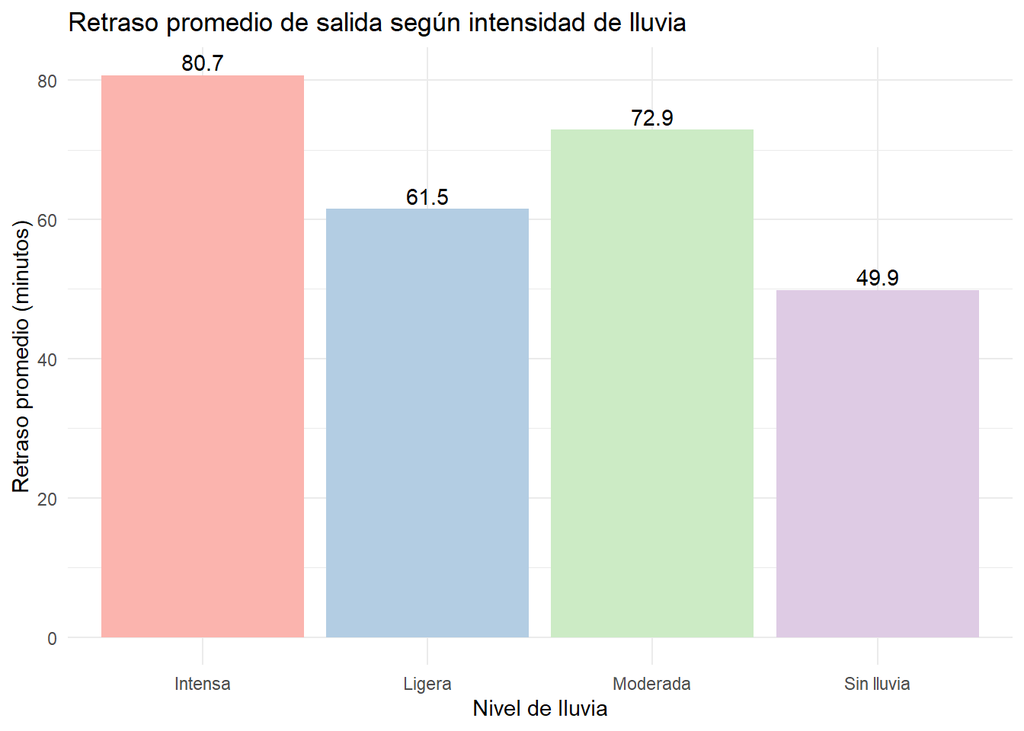

```r
ggplot(q17,
       aes(x = nivel_lluvia,
           y = promedio_dep,
           fill = nivel_lluvia)) +
  geom_col() +
  geom_text(aes(label = round(promedio_dep,1)),
            vjust = -0.3) +
  scale_fill_brewer(palette = "Pastel1") +
  labs(
    title = "Retraso promedio de salida según intensidad de lluvia",
    x = "Nivel de lluvia",
    y = "Retraso promedio (minutos)"
  ) +
  theme_minimal() +
  theme(legend.position = "none")
```

La precipitación fue clasificada en distintos niveles con base en la intensidad registrada en la variable precip. Valores cercanos a cero representan ausencia de lluvia, mientras que valores mayores indican incrementos en la intensidad de precipitación. Esto permite analizar cómo diferentes niveles de lluvia afectan los retrasos de salida y llegada.

Se observa que los vuelos realizados en condiciones de lluvia intensa presentan los mayores retrasos promedio, con aproximadamente 80.7 minutos de retraso en salida y 82.8 minutos en llegada. Esto sugiere que condiciones climáticas más severas afectan significativamente las operaciones aéreas.

En condiciones de lluvia moderada, los retrasos también son elevados, aunque menores que en lluvia intensa, con promedios cercanos a 73 minutos en salida y 80.6 minutos en llegada.

Por otro lado, los vuelos con lluvia ligera presentan retrasos promedio menores, mientras que los vuelos sin lluvia registran los niveles más bajos de demora, con aproximadamente 49.9 minutos de retraso de salida y 50.1 minutos de retraso de llegada.

En general, los resultados dan a una relación positiva entre la intensidad de la precipitación y el incremento en los retrasos de los vuelos: conforme aumenta la lluvia, las demoras tienden a ser mayores.

# Pregunta 18.

### ¿Cómo afecta la temperatura a los retrasos de los vuelos?

## Consulta con dplyr

**Mostrar código**

```r
q18 <- vuelos %>%
  inner_join(clima, by = c("origin", "time_hour")) %>%
  filter(!is.na(temp), !is.na(dep_delay),dep_delay > 0) %>%
  summarise(
    corr_temp_dep = cor(temp, dep_delay, use = "complete.obs")
  )
q18
```

| corr_temp_dep |
| --- |
| 0.06892072 |

## Consulta con SQL

**Mostrar código**

```r
dbGetQuery(con, "
SELECT
  (AVG(c.temp * v.dep_delay) - AVG(c.temp) * AVG(v.dep_delay)) /
  NULLIF(
    SQRT(AVG(c.temp * c.temp) - AVG(c.temp) * AVG(c.temp)) *
    SQRT(AVG(v.dep_delay * v.dep_delay) - AVG(v.dep_delay) * AVG(v.dep_delay)),
    0
  ) AS corr_temp_dep

FROM vuelos AS v
JOIN clima AS c
  ON v.origin = c.origin
 AND v.time_hour = c.time_hour

WHERE v.dep_delay > 0
  AND c.temp IS NOT NULL;
           ")
```

| corr_temp_dep |
| --- |
| 0.06892072 |

La correlación entre la temperatura y los retrasos de los vuelos es de *0.0689*, lo que indica una relación positiva muy débil. Es decir, no se tiene un impacto relevante en los retrasos de los vuelos desde NYC.

# Pregunta 19.

### ¿Cómo afectan los niveles de visibilidad a los retrasos en la llegada?

## Consulta con dplyr

**Mostrar código**

```r
q19 <- vuelos %>%
  left_join(clima, by = c("origin", "time_hour")) %>%
  filter(!is.na(visib), !is.na(arr_delay),arr_delay>0) %>%
  summarise(
    corr_visib_arr = cor(visib, arr_delay, use = "complete.obs")
  )
q19
```

| corr_visib_arr |
| --- |
| -0.1041727 |

## Consulta con SQL

**Mostrar código**

```r
dbGetQuery(con,"
SELECT
  (AVG(c.visib * v.arr_delay) - AVG(c.visib) * AVG(v.arr_delay)) /
  NULLIF(
    SQRT(AVG(c.visib * c.visib) - AVG(c.visib) * AVG(c.visib)) *
    SQRT(AVG(v.arr_delay * v.arr_delay) - AVG(v.arr_delay) * AVG(v.arr_delay)),
    0
  ) AS corr_visib_arr
FROM vuelos AS v
JOIN clima AS c
  ON v.origin = c.origin
 AND v.time_hour = c.time_hour
WHERE v.arr_delay IS NOT NULL
  AND c.visib IS NOT NULL
  AND v.arr_delay>0;
           ")
```

| corr_visib_arr |
| --- |
| -0.1041727 |

La correlación entre la visibilidad y los retrasos en la llegada es de *-0.1042*, lo que indica una relación negativa débil. Esto sugiere que, en general, cuando la visibilidad disminuye, los retrasos tienden a aumentar ligeramente, aunque la relación no es fuerte.

Esto sugiere que condiciones de menor visibilidad pueden contribuir ligeramente a mayores retrasos, por lo tanto, aunque la visibilidad puede influir en los retrasos de los vuelos, no parece ser un factor determinante por sí solo, ya que otros elementos como el tráfico aéreo, las condiciones climáticas generales o factores operativos también afectan las demoras.

# Pregunta 20.

### ¿La alta humedad se relaciona de alguna manera con los tiempos de taxi-out más largos?

## Consulta con dplyr

**Mostrar código**

```r
q20 <- vuelos %>%
  mutate(proxy_taxi_out = arr_delay - dep_delay) %>%
  left_join(clima, by = c("origin", "time_hour")) %>%
  filter(!is.na(humid), !is.na(dep_delay), !is.na(arr_delay)) %>%

  summarise(
    corr_humid_dep = cor(humid, proxy_taxi_out, use = "complete.obs")
  )
q20
```

| corr_humid_dep |
| --- |
| 0.08983275 |

## Consulta con SQL

**Mostrar código**

```r
dbGetQuery(con, "
SELECT
  (
    AVG(c.humid * (v.arr_delay - v.dep_delay)) -
    AVG(c.humid) * AVG(v.arr_delay - v.dep_delay)
  ) /
  NULLIF(
    SQRT(AVG(c.humid * c.humid) - AVG(c.humid) * AVG(c.humid)) *
    SQRT(
      AVG((v.arr_delay - v.dep_delay) * (v.arr_delay - v.dep_delay)) -
      AVG(v.arr_delay - v.dep_delay) * AVG(v.arr_delay - v.dep_delay)
    ),
    0
  ) AS corr_humid_taxi

FROM vuelos AS v
JOIN clima AS c
  ON v.origin = c.origin
 AND v.time_hour = c.time_hour

WHERE c.humid IS NOT NULL
  AND v.arr_delay IS NOT NULL
  AND v.dep_delay IS NOT NULL;
")
```

| corr_humid_taxi |
| --- |
| 0.08983275 |

La correlación entre la humedad y el tiempo de taxi-out fue de *0.08983275*, lo que indica una relación positiva muy débil. Esto sugiere que, conforme aumenta la humedad, el tiempo de taxi-out tiende a incrementarse ligeramente.

Esto indica que la humedad por sí sola no explica de manera importante las variaciones en el tiempo de taxi-out, y que probablemente intervienen otros factores operativos y climáticos, como el tráfico aéreo, las condiciones de pista o la congestión aeroportuaria.

# Gráfico de correlación

**Mostrar código**

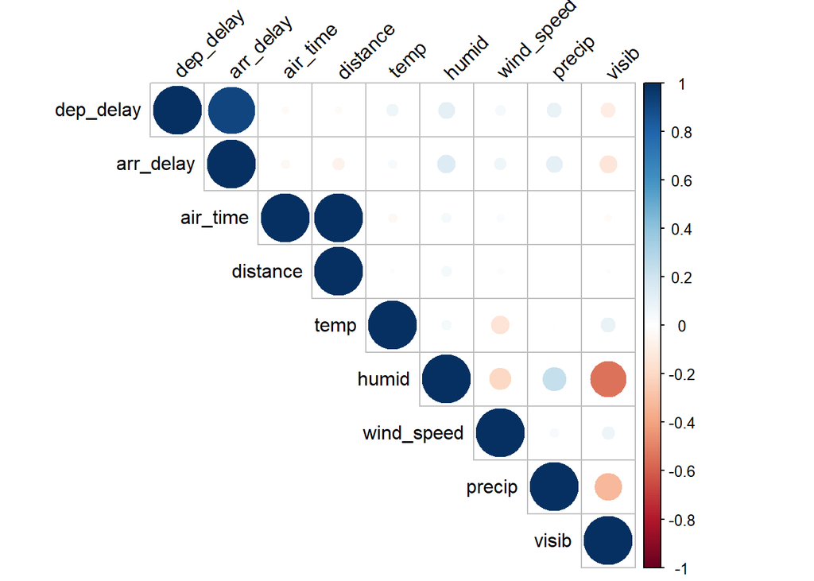

```r
datos_corr.1 <- vuelos %>%
  left_join(clima, by = c("origin", "time_hour")) %>%
  select(
    dep_delay,
    arr_delay,
    air_time,
    distance,
    temp,
    humid,
    wind_speed,
    precip,
    visib
  ) %>%
  na.omit()

matriz_corr.1 <- cor(datos_corr.1)

corrplot(
  matriz_corr.1,
  method = "circle",
  type = "upper",
  tl.col = "black",
  tl.srt = 45
)
```

En general, para ver la variación de la información consideramos la totalidad de los valores en retrasos:

*dep_delay (retraso de salida) vs. arr_delay (retraso de llegada):* Existe una correlación positiva extremadamente fuerte. Es decir, un retraso en la salida de un vuelo es el principal factor para un retraso en la llegada.

*air_time (tiempo en el aire) vs. distance (distancia):* Muestra una correlación positiva.A mayor distancia geográfica entre destinos, mayor es el tiempo que el avión pasa en el aire.

*humid (humedad) vs. visib (visibilidad):* Se observa un círculo de tamaño mediano rojizo/marrón. A mayor humedad en el ambiente, la visibilidad tiende a disminuir, lo cual tiene sentido meteorológico (por ejemplo, la formación de niebla o bruma).

*precip (precipitación) vs. visib (visibilidad):* Muestra un color rojizo/marrón claro, lo que indica que los días con mayores lluvias o precipitaciones reducen directamente la visibilidad en los aeropuertos.